# Computational Statistics

# Bootstrap

### Überprüfung des Zentralen Grenzwertsatzes

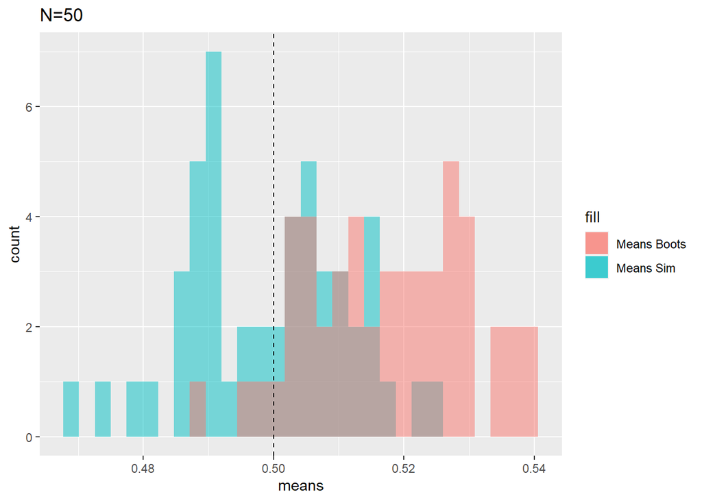

```r
library(ggplot2)
set.seed(1)

means_sim_50 <- c()
for(i in 1:50){
  sim_data <- runif(500)
  means_sim_50 <- c(means_sim_50, mean(sim_data))
}

means_sim_1000 <- c()
for(i in 1:1000){
  sim_data <- runif(500)
  means_sim_1000 <- c(means_sim_1000, mean(sim_data))
}

sim_500 <- runif(500)
num_replicates <- 50
means_boots_50 <- numeric(num_replicates)

# bootstrap
for(i in 1:num_replicates){
  bootstrap_sample <- sample(sim_500, replace=TRUE)
  means_boots_50[i] <- mean(bootstrap_sample)
}

num_replicates <- 1000
means_boots_1000 <- numeric(num_replicates)
for(i in 1:num_replicates){
  bootstrap_sample <- sample(sim_500, replace=TRUE)
  means_boots_1000[i] <- mean(bootstrap_sample)
}


ggplot() +
  geom_histogram(data=data.frame(means=means_sim_50),aes(x=means,fill="Means Sim"), alpha=0.5) +
  geom_histogram(data=data.frame(means=means_boots_50),aes(x=means,fill="Means Boots"), alpha=0.5) +
  geom_vline(xintercept = 0.5, linetype = "dashed") +
  ggtitle("N=50")
```

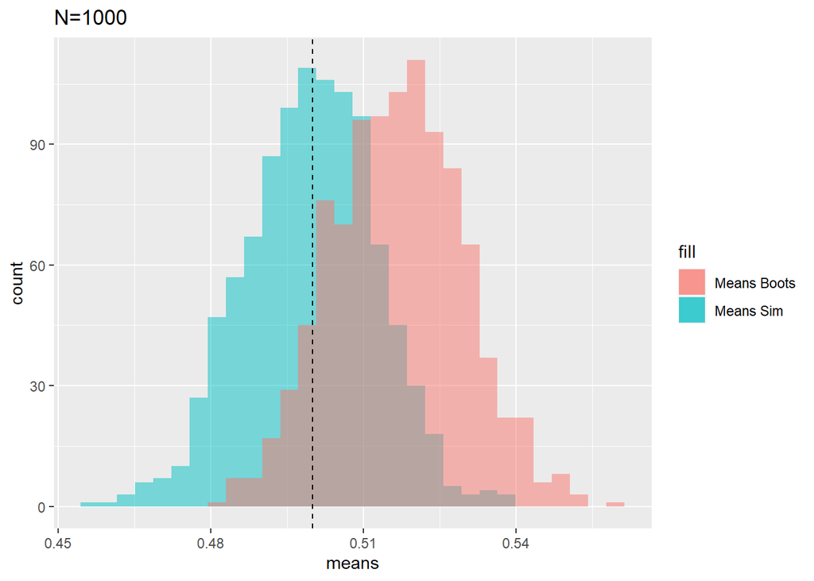

```r
ggplot() +
  geom_histogram(data=data.frame(means=means_sim_1000),aes(x=means,fill="Means Sim"), alpha=0.5) +
  geom_histogram(data=data.frame(means=means_boots_1000),aes(x=means,fill="Means Boots"), alpha=0.5) +
  geom_vline(xintercept = 0.5, linetype = "dashed") +
  ggtitle("N=1000")
```

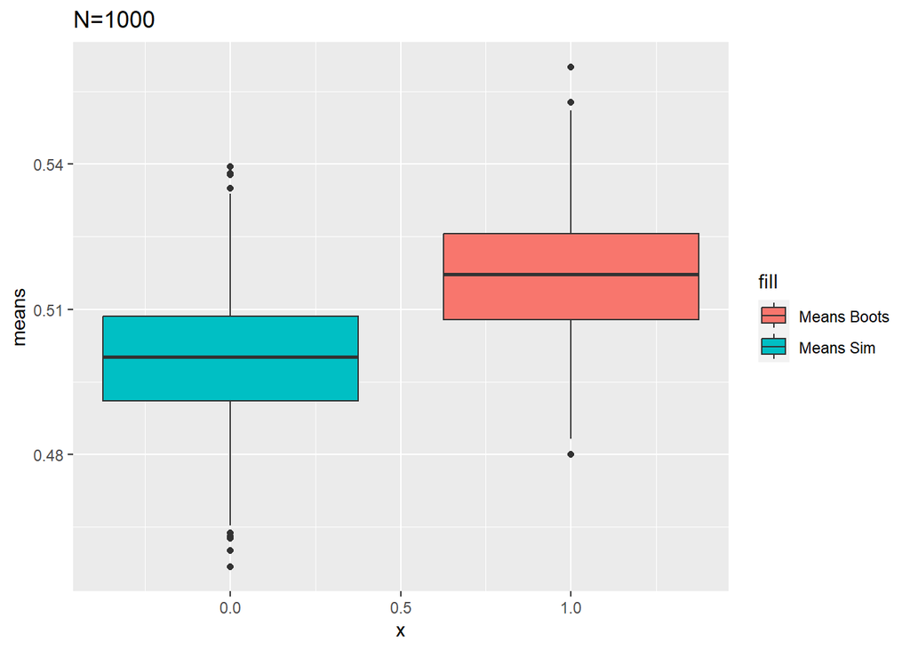

```r
ggplot() +
  geom_boxplot(data=data.frame(means=means_sim_1000),aes(x=0,y=means,fill="Means Sim"),) +
  geom_boxplot(data=data.frame(means=means_boots_1000),aes(x=1,y=means,fill="Means Boots")) +
  ggtitle("N=1000")
```

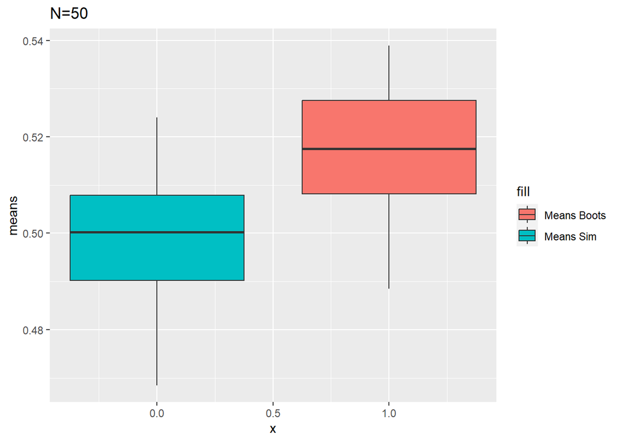

```r
ggplot() +
  geom_boxplot(data=data.frame(means=means_sim_50),aes(x=0,y=means,fill="Means Sim"),) +
  geom_boxplot(data=data.frame(means=means_boots_50),aes(x=1,y=means,fill="Means Boots")) +
  ggtitle("N=50")
```

Die Bootstrap Methode ist nicht so präzise, wie die Simulationen. Der Mittelwert des gleichverteilten Datensatzes, der für das Bootstrapping genutzt wurde liegt bei 0.5169. Das 0.25-Quantil der Bootstrap-Verteilung ist bei etwa 0.51. Damit ist die Verteilung der Bootstrap Mittelwerte deutlich höher, als die der simulierten Mittelwerte.

#### Test auf Normalverteilung

```r
print("N = 50")
```

```
## [1] "N = 50"
```

```r
shapiro.test(means_sim_50)
```

```
##
##  Shapiro-Wilk normality test
##
## data:  means_sim_50
## W = 0.98221, p-value = 0.6482
```

```r
shapiro.test(means_boots_50)
```

```
##
##  Shapiro-Wilk normality test
##
## data:  means_boots_50
## W = 0.97764, p-value = 0.4574
```

```r
print("N = 1000")
```

```
## [1] "N = 1000"
```

```r
shapiro.test(means_sim_1000)
```

```
##
##  Shapiro-Wilk normality test
##
## data:  means_sim_1000
## W = 0.99823, p-value = 0.3934
```

```r
shapiro.test(means_boots_1000)
```

```
##
##  Shapiro-Wilk normality test
##
## data:  means_boots_1000
## W = 0.99867, p-value = 0.6655
```

Da der p-Wert > 0.05 ist, sind die Mittelwerte normalverteilt. Das Ergebnis wird durch den zentralen Grenzwertsatz begründet.

#### t-Test der Mittelwerte

```r
print("N = 50")
```

```
## [1] "N = 50"
```

```r
t.test(means_sim_50, means_boots_50)
```

```
##
##  Welch Two Sample t-test
##
## data:  means_sim_50 and means_boots_50
## t = -7.3917, df = 97.962, p-value = 4.923e-11
## alternative hypothesis: true difference in means is not equal to 0
## 95 percent confidence interval:
##  -0.02312871 -0.01333829
## sample estimates:
## mean of x mean of y
## 0.4991870 0.5174205
```

```r
print("N = 1000")
```

```
## [1] "N = 1000"
```

```r
t.test(means_sim_1000, means_boots_1000)
```

```
##
##  Welch Two Sample t-test
##
## data:  means_sim_1000 and means_boots_1000
## t = -29.957, df = 1998, p-value < 2.2e-16
## alternative hypothesis: true difference in means is not equal to 0
## 95 percent confidence interval:
##  -0.01823899 -0.01599766
## sample estimates:
## mean of x mean of y
## 0.4996710 0.5167893
```

Nach den t-Tests gibt es einen signifikanten Unterschied zwischen den Mittelwerten der Simulationen und der Mittelwerte des Bootstrapping. Die Bootstrap-Methode basiert auf der Annahme, dass die Stichprobe (der Datensatz vom Umfang 500) eine gute Schätzung für die zugrundeliegende Gleichverteilung ist. Wie an den bereits generierten Plots zu erkennen ist, ist die Stichprobe größtenteils über dem erwarteten Wert 0.5 und daher gleichen die Mittelwerte der Bootstrap-Methode nicht den simulierten Mittelwerten.

### Konfidenzintervalle durch Bootstrapping

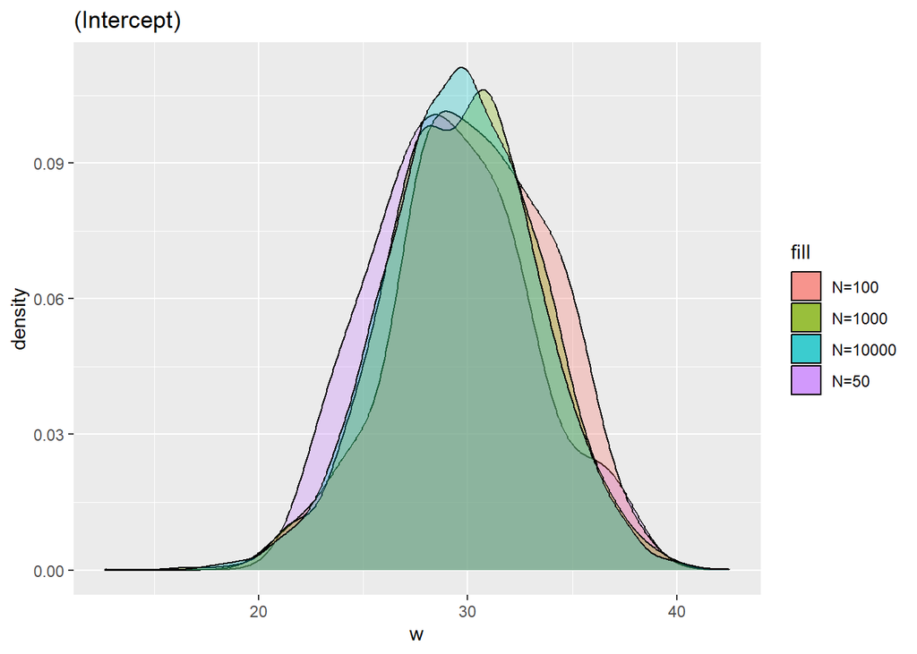

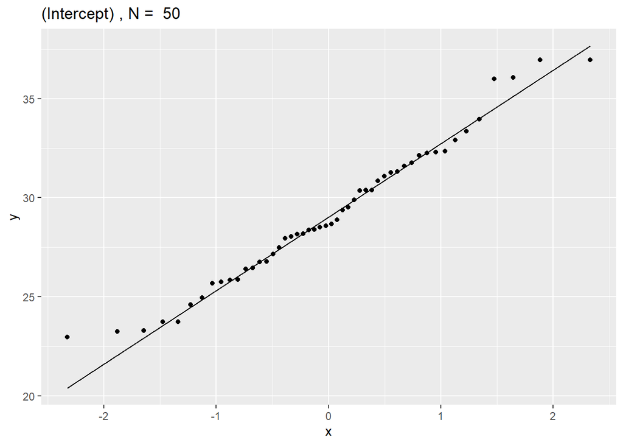

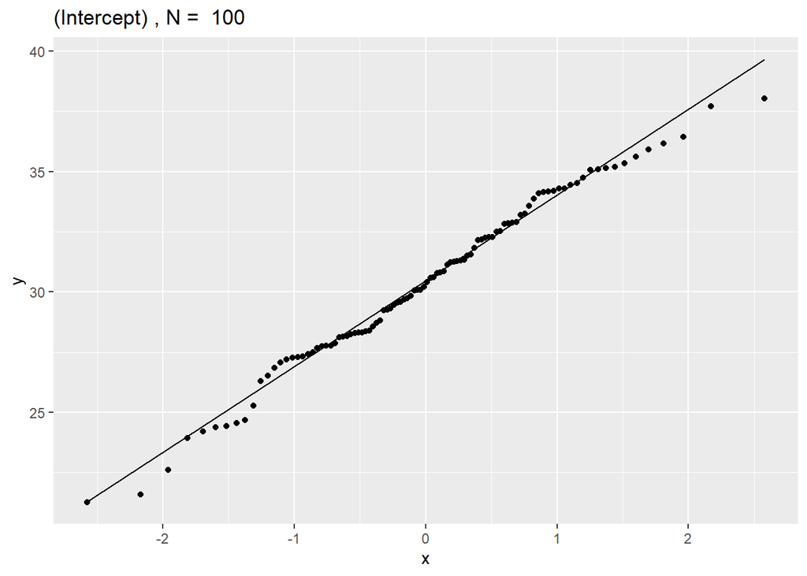

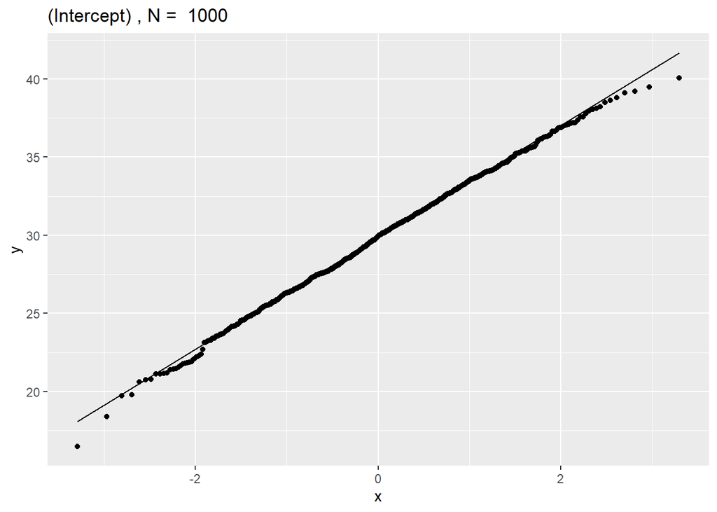

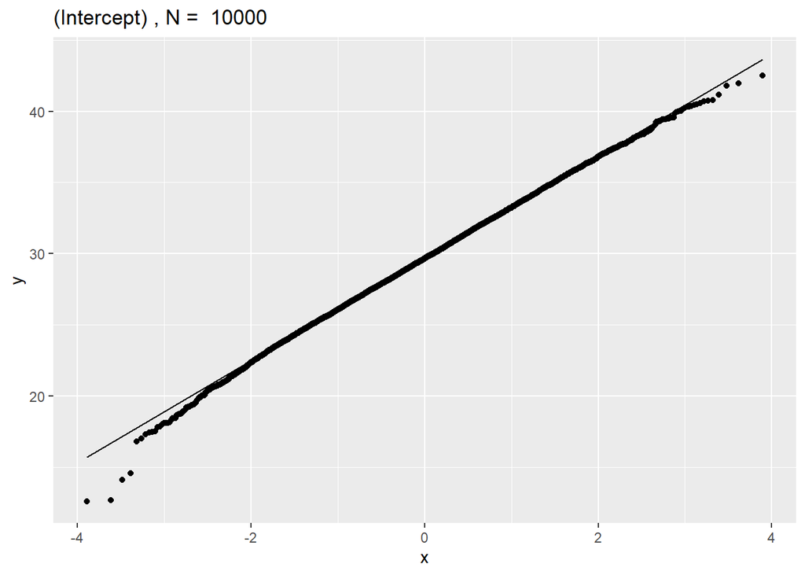

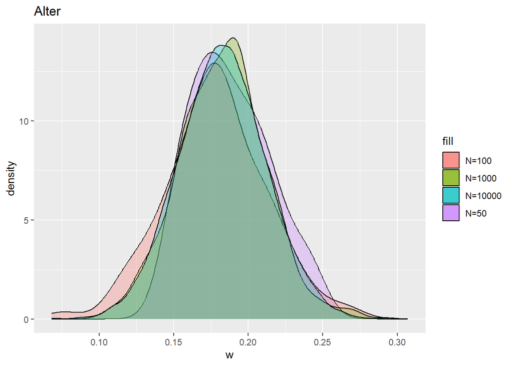

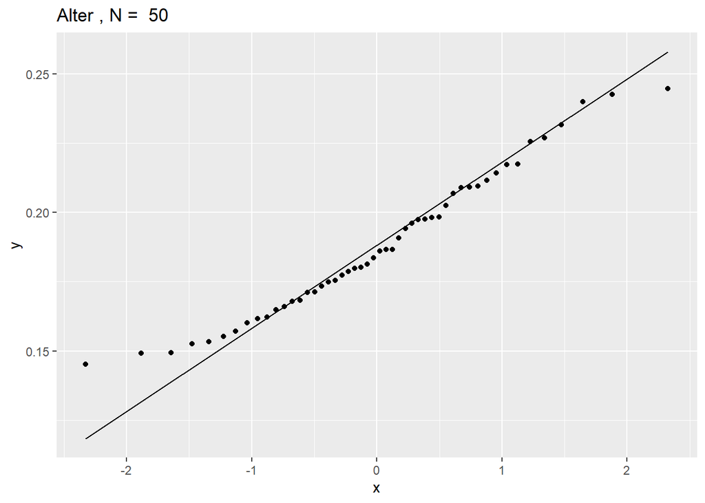

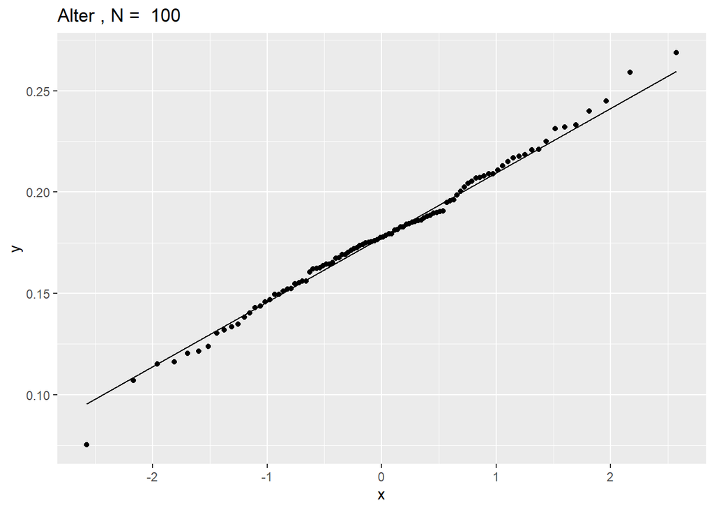

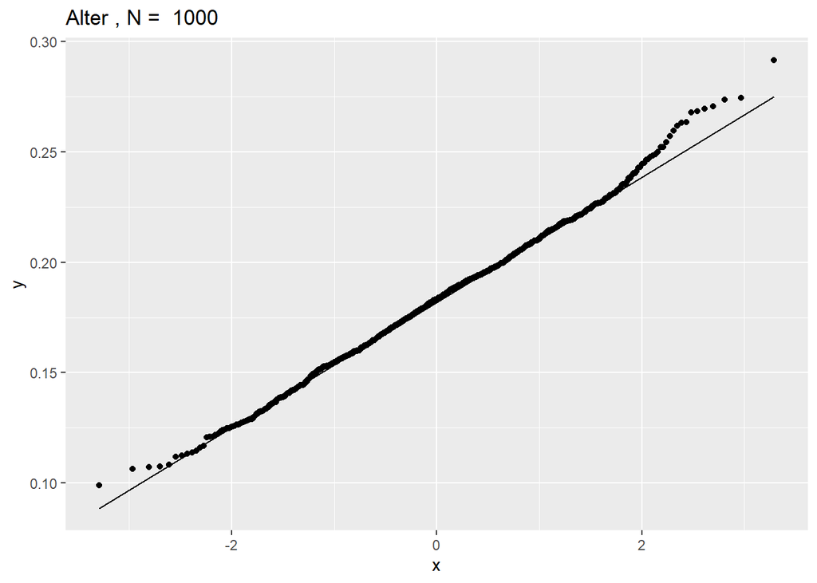

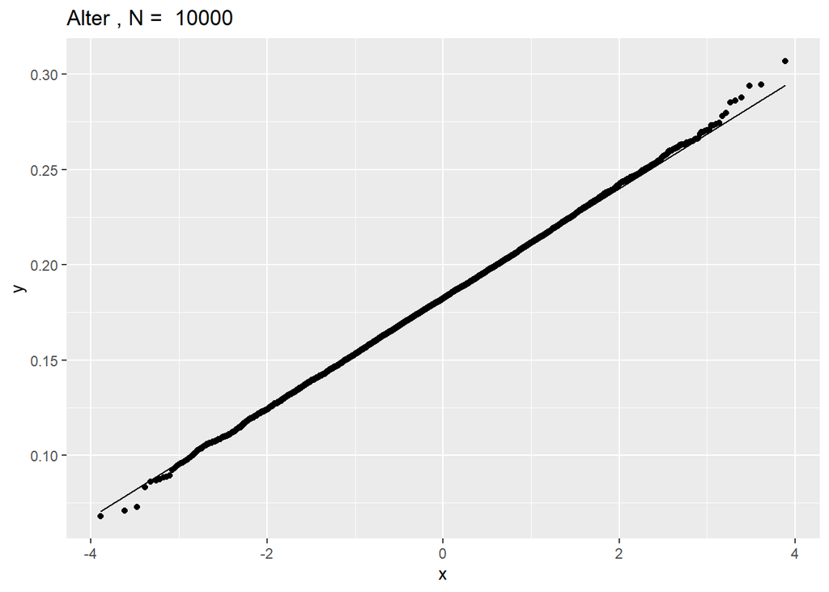

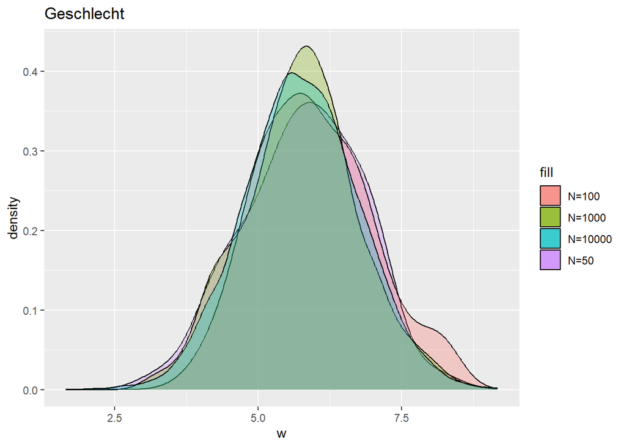

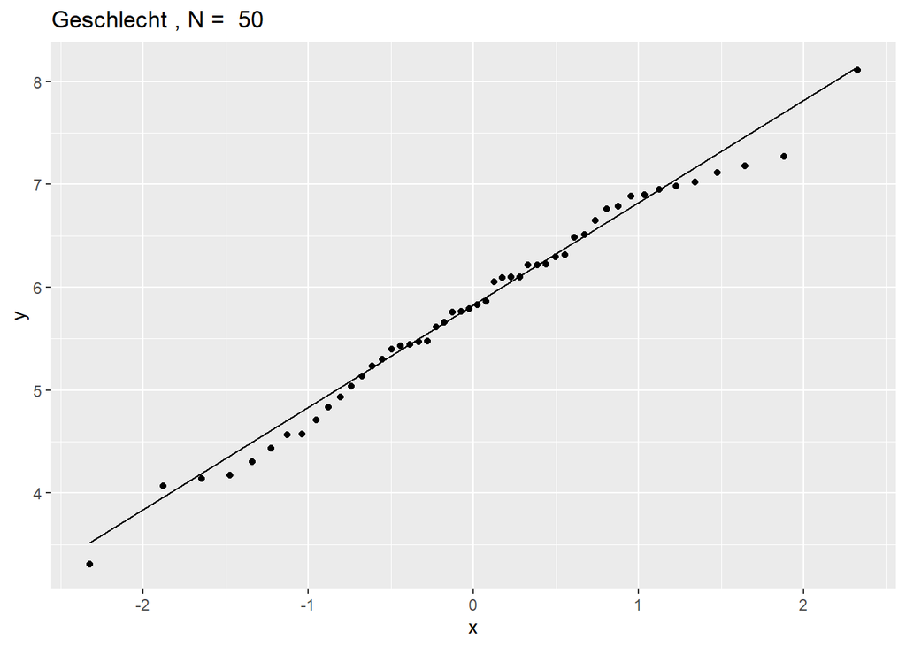

[18 more figures not shown]

```r
load("data/Donald.RData")
library(boot)

data <- Donald_1
model <- lm(Trump~Alter+Geschlecht+Minderheit+Fremdenfeindlich+IQ, data=data)
coef_names <- names(model$coefficients[1:6])

# Anzahl der Replikationen für den Bootstrap
n_bootstrap <- c(50, 100, 1000, 10000)

bootstrap_coef <- function(formula, data, indices){
  d <- data[indices,]
  fit <- lm(formula, data=d)
  return(coef(fit))
}


result <- list()
for(ni in n_bootstrap){
  reps <- boot(data=data, statistic=bootstrap_coef, R=ni, formula=model$call$formula)
  result[[ni]] <- reps
}

for(i in seq_along(coef_names)){
  histogram <- ggplot() +
    geom_density(data=data.frame(w=result[[50]]$t[,i]), mapping=aes(x=w, y=..density..,fill="N=50"), alpha=0.3) +
    geom_density(data=data.frame(w=result[[100]]$t[,i]), mapping=aes(x=w, y=..density.., fill="N=100"), alpha=0.3) +
    geom_density(data=data.frame(w=result[[1000]]$t[,i]), mapping=aes(x=w, y=..density.., fill="N=1000"), alpha=0.3) +
    geom_density(data=data.frame(w=result[[10000]]$t[,i]), mapping=aes(x=w, y=..density.., fill="N=10000"), alpha=0.3) +
    ggtitle(coef_names[i])

  print(histogram)
  for(ni in n_bootstrap){
  qq_plot <- ggplot(data=data.frame(w=result[[ni]]$t[,i]), mapping=aes(sample=w))+
    stat_qq() +
    stat_qq_line() +
    ggtitle(paste(coef_names[i], ", N = ", as.character(ni) ))

  print(qq_plot)
  }


}
```

Je größer N gewählt wird, desto näher sind die Koeffizienten-Schätzer normalverteilt.

```r
col_names <- c("n", "LL","UL", "Error_LL", "Error_UL", "Total_Diff_lm")

ci_lm <- confint(model)

for(i in seq_along(coef_names))
  {
    df <- data.frame(matrix(ncol = length(col_names), nrow = 0))

    for(ni in n_bootstrap){

      boot_ci <- boot.ci(result[[ni]], type="basic", index=i)
      ci <- tail(as.vector(boot_ci$basic), 2)
      df <- rbind(df,c(ni,ci, ci-ci_lm[i,],sum(abs(ci-ci_lm[i,]))))
    }
    colnames(df) <- col_names
    print(coef_names[i])
    print(df)
  }
```

```
## [1] "(Intercept)"
##       n       LL       UL     Error_LL    Error_UL Total_Diff_lm
## 1    50 22.51842 36.41338 -0.085024597 -0.45985889     0.5448835
## 2   100 22.48129 37.31893 -0.122155351  0.44569360     0.5678490
## 3  1000 22.61288 37.21595  0.009434234  0.34271529     0.3521495
## 4 10000 22.84896 36.95315  0.245514592  0.07990643     0.3254210
## [1] "Alter"
##       n        LL        UL      Error_LL     Error_UL Total_Diff_lm
## 1    50 0.1190041 0.2165262 -0.0022558711 -0.025267089   0.027522960
## 2   100 0.1120515 0.2515150 -0.0092085043  0.009721663   0.018930167
## 3  1000 0.1202946 0.2370037 -0.0009653898 -0.004789595   0.005754984
## 4 10000 0.1224300 0.2376156  0.0011699586 -0.004177710   0.005347668
## [1] "Geschlecht"
##       n       LL       UL     Error_LL     Error_UL Total_Diff_lm
## 1    50 3.684817 7.946383 -0.094778838  0.214539470    0.30931831
```

[output cut: 21 more lines]

```r
n <- 1000
options <- c("basic", "bca", "perc")
col_names <- c("n", "LL","UL", "Total_Diff_lm", "options")

for(i in seq_along(coef_names))
  {
    df <- data.frame(matrix(ncol = length(col_names), nrow = 0))

    for(x in options){

      boot_ci <- boot.ci(result[[n]], type=x, index=i)
      if(x == "basic") {ci <- tail(as.vector(boot_ci$basic), 2)}
      else{
      if(x == "bca") ci <- tail(as.vector(boot_ci$bca), 2)
      else ci <- tail(as.vector(boot_ci$perc), 2)
      }

      df <- rbind(df,c(ni,ci, sum(abs(ci-ci_lm[i,])), x))
    }
    colnames(df) <- col_names
    print(coef_names[i])
    print(df)
  }
```

```
## [1] "(Intercept)"
##       n               LL               UL     Total_Diff_lm options
## 1 10000 22.6128828890576 37.2159549959097 0.352149521350952   basic
## 2 10000 22.3297794714772 36.8833535063158 0.283782980616913     bca
## 3 10000 22.2607333677066 36.8638054745587 0.352149521350956    perc
## [1] "Alter"
##       n                LL                UL       Total_Diff_lm options
## 1 10000 0.120294601981395 0.237003721206405 0.00575498437054951   basic
## 2 10000  0.12372829279777 0.235354910200375 0.00890670663476087     bca
## 3 10000 0.126049586351944 0.242758705576955 0.00575498437054948    perc
## [1] "Geschlecht"
##       n               LL               UL      Total_Diff_lm options
## 1 10000 3.75535278419758  7.7237071352967 0.0323796480354739   basic
## 2 10000 3.74023252849176  7.7323257062684 0.0398450931144176     bca
## 3 10000 3.78773243223306 7.75608678333217 0.0323796480354743    perc
## [1] "Minderheit"
##       n                LL                UL    Total_Diff_lm options
## 1 10000 -9.52327187611247  -3.3502610406858 1.05505296281453   basic
## 2 10000 -9.80392930705009 -3.63477432726517 1.05890881845628     bca
## 3 10000 -9.80146399841686 -3.62845316299019 1.05505296281453    perc
## [1] "Fremdenfeindlich"
##       n               LL               UL      Total_Diff_lm options
## 1 10000 8.99299610346947 9.71643412794366 0.0780752033906857   basic
## 2 10000 8.98660187285418 9.71087407914562 0.0789093852079379     bca
## 3 10000 8.98324208847277 9.70668011294696 0.0780752033906857    perc
## [1] "IQ"
##       n                 LL                 UL       Total_Diff_lm options
## 1 10000 -0.465471005907476 -0.339453379345907 0.00680523809383887   basic
## 2 10000 -0.470020154663746 -0.341488710222682 0.00931905597333332     bca
## 3 10000 -0.463246032360683 -0.337228405799114 0.00680523809383887    perc
```

*basic* basiert auf der Annahme, dass die Bootstrap-Verteilung der Schätzwerte ungefähr symmetrisch ist.

*bca* korrigiert den Verzehrrungsfehler und berücksichtigt die Beschleunigung der Bootstrap-Verteilung. Bietet eine verbesserte Genauigkeit, wenn die Bootstrap-Verteilung nicht symmetrisch ist oder die Schätzwerte eine nicht-lineare Beziehung zu den Daten aufweisen.

*perc* verwendet ausschließlich die Perzentile der Bootstrapping-Verteilung für die Schätzung der Konfidenzintervalle. Keine Korrektur für Verzerrung oder Beschleunigung.

Die Option *perc* gibt zwar andere Konfidenzintervalle an, aber ist von der Genauigkeit zur linearen Regression genauso gut wie die Option *basic*. Je nach Variable ist einer der Optionen näher an den Konfidenzintervallen der linearen Regression, deswegen wird sich an der Stelle für keine Option entschieden.

# Shrinkage

### Ridge Regression

Ridge Regression wird genutzt, wenn Multikollinearität in den Daten existiert. Ridge Regression minimiert:

**die Summe der quadrierten Residuen + λ * Summe der quadrierten Koeffizienten**

Der zweite Term nennt sich shrinkage penalty. Lambda bestimmt die Regularisierung der Koeffizienten. Je höher λ gewählt wird, desto mehr schrumpfen die Koeffizienten der Ridge Regression.

```r
set.seed(1)
load("data/prostate.rdata")
library(glmnet)
library(ggplot2)

# lineare Regression
lm_model <- lm(lpsa~lcavol+lweight+age+lbph+svi+lcp+gleason+pgg45, data=prostate)
lm_coef <- coef(lm_model)

#ridge Regression
y <- prostate$lpsa
x <- data.matrix(prostate[,c('lcavol','lweight','age','lbph','svi','lcp','gleason','pgg45')])
rr_model_lambda_0 <- glmnet(x,y,alpha=0,lambda=0) # alpha=0 => Ridge Regression
rr_model_lambda_10 <- glmnet(x,y,alpha=0,lambda=10)
result <- data.frame(Lineare.Regression=lm_model$coefficients,
                     Ridge.Regression.lambda0=as.vector(coef(rr_model_lambda_0)),
                     Ridge.Regression.lambda10=as.vector(coef(rr_model_lambda_10)))

print(result)
```

```
##             Lineare.Regression Ridge.Regression.lambda0
## (Intercept)        0.181560862              0.179531072
## lcavol             0.564341279              0.564271417
## lweight            0.622019787              0.622218451
## age               -0.021248185             -0.021251155
## lbph               0.096712523              0.096678106
## svi                0.761673403              0.761615376
## lcp               -0.106050939             -0.106066349
## gleason            0.049227933              0.049475128
## pgg45              0.004457512              0.004454923
##             Ridge.Regression.lambda10
## (Intercept)               1.536807719
## lcavol                    0.064394837
## lweight                   0.106582457
## age                       0.001718267
## lbph                      0.012817952
## svi                       0.135335780
## lcp                       0.036490103
## gleason                   0.044694072
## pgg45                     0.001324128
```

Die Koeffienzen des linearen Regressionsmodells sind bis auf den Intercept identisch zum Ridge Regressionmodell mit lambda=0, weil der Strafterm der Ridge Regression entfällt und deshalb wie eine lineare Regression funktionieren. Das der Intercept ungleich ist, liegt vermutlich daran, dass die Funktion *glmnet* anders implementiert wurde als *lm*. Die Koeffizienten des Ridge Regression-Modells mit lambda=10 schrumpfen, sodass sie weniger Einfluss auf die Zielvariable *lpsa* haben.

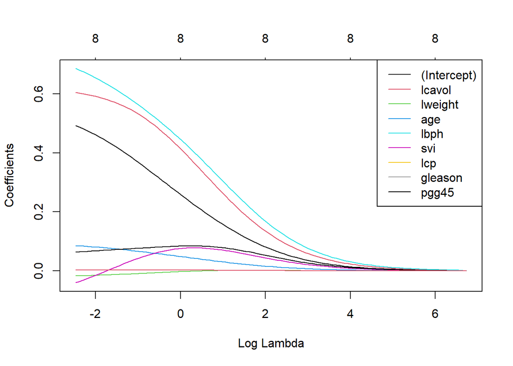

```r
rr_model <- glmnet(x,y,alpha=0)
plot(rr_model, xvar="lambda")

legend("topright", legend = rownames(coef(rr_model_lambda_10)), col = 1:nrow(coef(rr_model_lambda_10)), lty = 1)
```

#### Cross Validation für λ = 0, λ = 0.09 und λ = 2

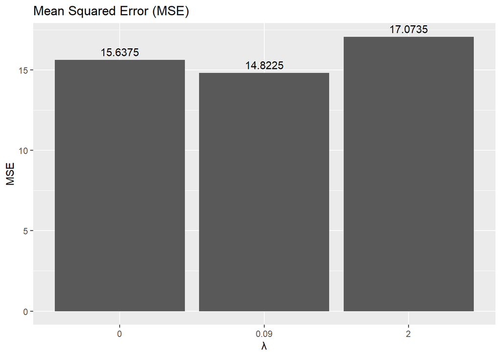

```r
lambdas <- c(0, 0.09, 2)
mse_estimates <- c()
for(lambda in lambdas){
  train_x <- x[prostate$train==TRUE,]
  train_y <- y[prostate$train==TRUE]
  test_x <- x[prostate$train==FALSE,]
  test_y <- y[prostate$train==FALSE]

  rr_model <- glmnet(train_x,train_y,alpha=0, lambda=lambda)
  estimates <- predict(rr_model,test_x)
  mse <- sum((test_y-estimates)**2)
  mse_estimates <- c(mse_estimates, mse)
}
# plot MSEs
ggplot(data.frame(MSE=round(mse_estimates, 4)), aes(x = as.character(lambdas), y = MSE)) +
  geom_bar(stat = "identity") +
  xlab("λ") +
  ylab("MSE") +
  ggtitle("Mean Squared Error (MSE)") +
  geom_text(aes(label=MSE), vjust=-0.5)
```

Der Test-MSE für λ = 0.09 ist im Vergleich zu den anderen Lambda-Werten am geringsten.

```r
#perform k-fold cross-validation to find optimal lambda value
cv_model <- cv.glmnet(x, y, alpha = 0)

#find optimal lambda value that minimizes test MSE
best_lambda <- cv_model$lambda.min
best_lambda
```

```
## [1] 0.08434274
```

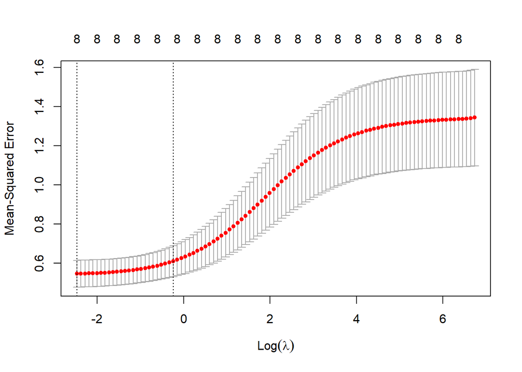

```r
#produce plot of test MSE by lambda value
plot(cv_model)
```

Das optimale λ liegt bei 0.08.

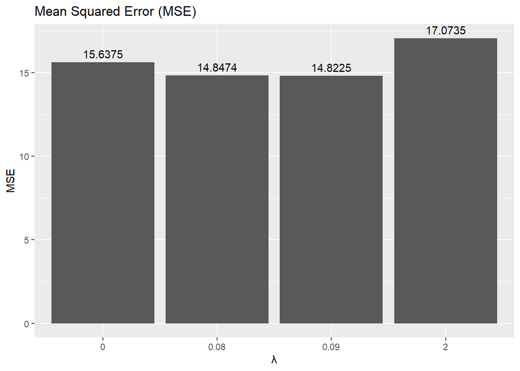

```r
set.seed(1)
rr_model_best_lambda <- glmnet(train_x, train_y, alpha = 0, lambda=best_lambda)
estimates <- predict(rr_model_best_lambda, test_x)
mse <- sum((test_y-estimates)**2)
mse_estimates <- c(mse_estimates, mse)

# plot MSEs
ggplot(data.frame(MSE=round(mse_estimates, 4)), aes(x = as.character(c(lambdas, "0.08")), y = MSE)) +
  geom_bar(stat = "identity") +
  xlab("λ") +
  ylab("MSE") +
  ggtitle("Mean Squared Error (MSE)") +
  geom_text(aes(label=MSE), vjust=-0.5)
```

Nach der k-Fold Cross Validation ist das optimale λ = 0.08. Mit einer einfachen Cross Validation konnte λ = 0.09 einen etwas niedrigeren MSE erhalten. Das optimale λ der k-Fold Cross Validation ist jedoch ein besserer Schätzer, da er ein stabileren MSE schätzt.

#### Vergleich der Koeffizenten

```r
data.frame(Koeffizienten.LineareRegression=coef(lm_model),Koeffizienten.best_lambda=as.vector(coef(rr_model_best_lambda)))
```

```
##             Koeffizienten.LineareRegression Koeffizienten.best_lambda
## (Intercept)                     0.181560862               0.104455298
## lcavol                          0.564341279               0.495335342
## lweight                         0.622019787               0.601861871
## age                            -0.021248185              -0.014961077
## lbph                            0.096712523               0.138248753
## svi                             0.761673403               0.681493597
## lcp                            -0.106050939              -0.119374792
## gleason                         0.049227933               0.016026912
## pgg45                           0.004457512               0.007142589
```

### Lasso Verfahren

Das Lasso-Verfahren nutzt im Vergleich zur Ridge Regression einen L1-Penalty-Term zur Regularisierung. Der L1-Penalty-Term ist proportional zur Summe der absoluten Werte der Koeffizienten. Während die Ridge Regression versucht die Koeffizienten gleichmäßig zu schrumpfen, zielt die Lasso-Methode irrelevante Prädiktoren aus dem Modell anhand eines Koeffizientenwerts von 0 zu eliminieren.

```r
lasso_model_lambda_0 <- glmnet(x,y,alpha=1,lambda=0) # alpha=1 => Lasso-Verfahren
lasso_model_lambda_10 <- glmnet(x,y,alpha=1,lambda=10)
result <- data.frame(Lineare.Regression=lm_model$coefficients,
                     Ridge.Regression.lambda0=as.vector(coef(rr_model_lambda_0)),
                     Ridge.Regression.lambda10=as.vector(coef(rr_model_lambda_10)),
                     Lasso.lambda0=as.vector(coef(lasso_model_lambda_0)),
                     Lasso.lambda10=as.vector(coef(lasso_model_lambda_10)))


print(result)
```

```
##             Lineare.Regression Ridge.Regression.lambda0
## (Intercept)        0.181560862              0.179531072
## lcavol             0.564341279              0.564271417
## lweight            0.622019787              0.622218451
## age               -0.021248185             -0.021251155
## lbph               0.096712523              0.096678106
## svi                0.761673403              0.761615376
## lcp               -0.106050939             -0.106066349
## gleason            0.049227933              0.049475128
## pgg45              0.004457512              0.004454923
##             Ridge.Regression.lambda10 Lasso.lambda0 Lasso.lambda10
## (Intercept)               1.536807719   0.179531072       2.478387
## lcavol                    0.064394837   0.564271417       0.000000
## lweight                   0.106582457   0.622218451       0.000000
## age                       0.001718267  -0.021251155       0.000000
## lbph                      0.012817952   0.096678106       0.000000
## svi                       0.135335780   0.761615376       0.000000
## lcp                       0.036490103  -0.106066349       0.000000
## gleason                   0.044694072   0.049475128       0.000000
## pgg45                     0.001324128   0.004454923       0.000000
```

#### Koeffizienten für verschiedene λ-Werte

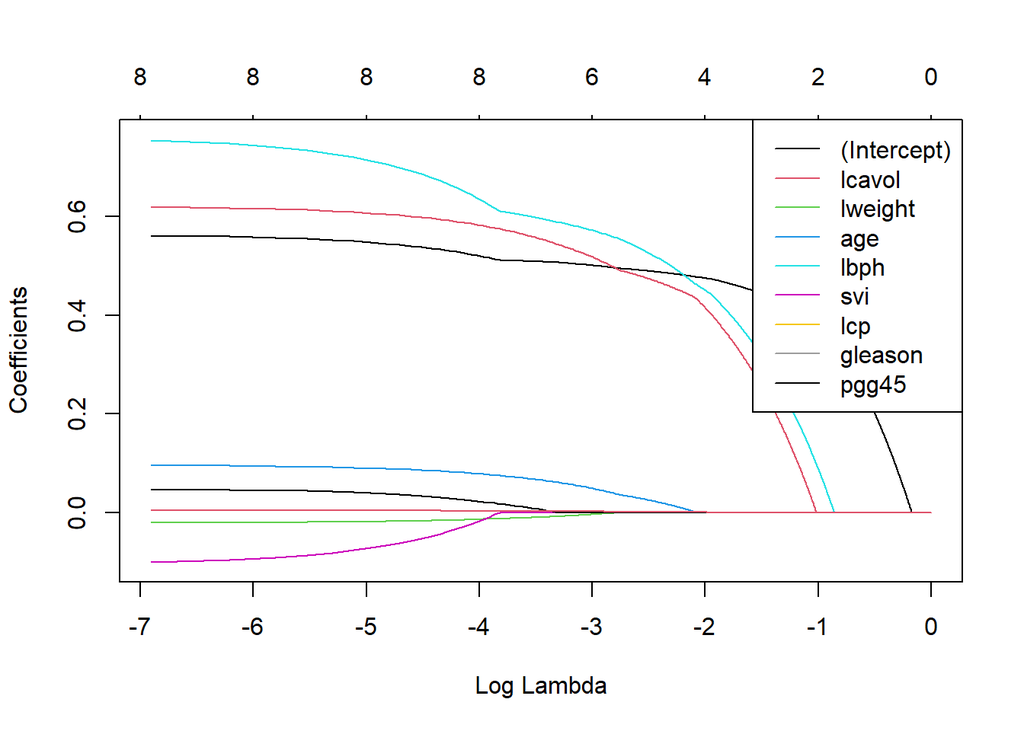

```r
lasso_model <- glmnet(x,y,alpha=1, lambda=seq(0,1,0.001))
plot(lasso_model, xvar="lambda")
legend("topright", legend = rownames(coef(lasso_model_lambda_0)), col = 1:nrow(coef(lasso_model_lambda_0)), lty = 1)
```

Mit steigendem λ werden die Koeffizientenschätzer nacheinander eliminiert.

#### Cross Validation für λ = 0, λ = 0.002 und λ = 1

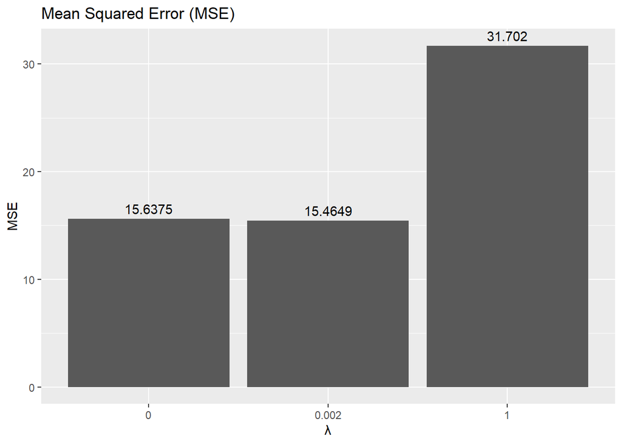

```r
lambdas <- c(0, 0.002, 1)
mse_estimates <- c()

# split into training und test
train_x <- x[prostate$train==TRUE,]
train_y <- y[prostate$train==TRUE]
test_x <- x[prostate$train==FALSE,]
test_y <- y[prostate$train==FALSE]

for(lambda in lambdas){

  lasso_model <- glmnet(train_x,train_y,alpha=1, lambda=lambda)
  estimates <- predict(lasso_model,test_x)
  mse <- sum((test_y-estimates)**2)
  mse_estimates <- c(mse_estimates, mse)
}
# plot MSEs
ggplot(data.frame(MSE=round(mse_estimates, 4)), aes(x = as.character(lambdas), y = MSE)) +
  geom_bar(stat = "identity") +
  xlab("λ") +
  ylab("MSE") +
  ggtitle("Mean Squared Error (MSE)") +
  geom_text(aes(label=MSE), vjust=-0.5)
```

λ = 0.002 hat den geringsten MSE nach der Cross Validation. λ = 1 hat etwa ein doppelt so hohen MSE zu λ = 0 und λ = 0.002.

#### Optimaler Schätzer für λ

```r
#perform k-fold cross-validation to find optimal lambda value
cv_model <- cv.glmnet(x, y, alpha = 1)

#find optimal lambda value that minimizes test MSE
best_lambda <- cv_model$lambda.min
best_lambda
```

```
## [1] 0.0824037
```

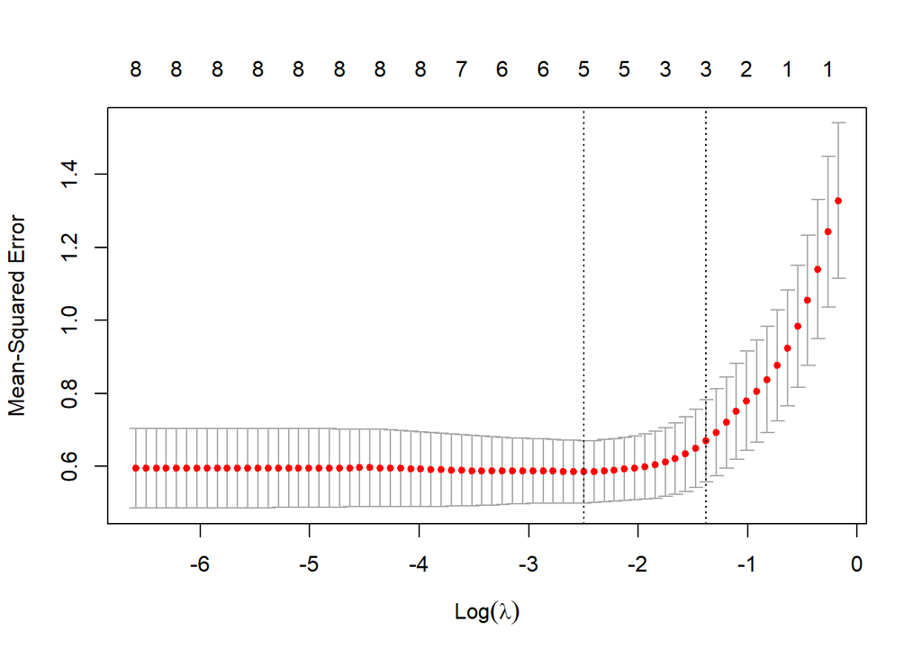

```r
#produce plot of test MSE by lambda value
plot(cv_model)
```

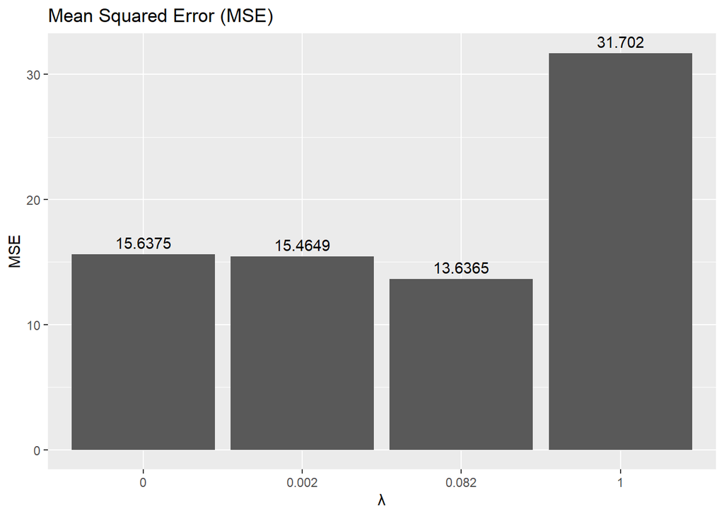

```r
lasso_model_best_lambda <- glmnet(train_x, train_y, alpha = 1, lambda=best_lambda)
estimates <- predict(lasso_model_best_lambda, test_x)
mse <- sum((test_y-estimates)**2)
mse_estimates <- c(mse_estimates, mse)

# plot MSEs
ggplot(data.frame(MSE=round(mse_estimates, 4)), aes(x = as.character(c(lambdas, as.character(round(best_lambda,3)))), y = MSE)) +
  geom_bar(stat = "identity") +
  xlab("λ") +
  ylab("MSE") +
  ggtitle("Mean Squared Error (MSE)") +
  geom_text(aes(label=MSE), vjust=-0.5)
```

Der Test-MSE ist mit optimalen λ kleiner als der Test-MSE der λ-Werte aus der einfachen Cross Validation.

# PCA/PLS Regression

Beschreibung der Variablen:

- lcavol: Tumorvolumen (logarithmiert)
- lweight: Tumorgewicht (logarithmiert)
- age: Alter des Patienten
- lbph: Anzahl der benignen Hyperplasien in der Prostata- das sind gutartige Veränderungen (logarithmiert)
- gleason: Gleason score - das ist ein Maß dafür, wie stark die Zellen der Prostata bereits verändert sind
- pgg45: Anteil des Tumors mit Gleason score 4 oder 5 (in Prozent)
- lpc: Anteil der Organkapsel, der bereits von Tumorzellen infiltriert ist (in Prozent)
- svi: Sind die Samenbläschen bereits infiltriert? (ja/nein)
- lpsa PSA Wert - abhängige Variable (logarithmiert)

### Korrelationsmatrix

```r
load("data/prostate.rdata")
library(dplyr)
cor(select(prostate, -c(train,lpsa)))
```

```
##            lcavol   lweight       age         lbph         svi          lcp
## lcavol  1.0000000 0.2805214 0.2249999  0.027349703  0.53884500  0.675310484
## lweight 0.2805214 1.0000000 0.3479691  0.442264395  0.15538491  0.164537146
## age     0.2249999 0.3479691 1.0000000  0.350185896  0.11765804  0.127667752
## lbph    0.0273497 0.4422644 0.3501859  1.000000000 -0.08584324 -0.006999431
## svi     0.5388450 0.1553849 0.1176580 -0.085843238  1.00000000  0.673111185
## lcp     0.6753105 0.1645371 0.1276678 -0.006999431  0.67311118  1.000000000
## gleason 0.4324171 0.0568821 0.2688916  0.077820447  0.32041222  0.514830063
## pgg45   0.4336522 0.1073538 0.2761124  0.078460018  0.45764762  0.631528246
##            gleason      pgg45
## lcavol  0.43241706 0.43365225
## lweight 0.05688210 0.10735379
## age     0.26889160 0.27611245
## lbph    0.07782045 0.07846002
## svi     0.32041222 0.45764762
## lcp     0.51483006 0.63152825
## gleason 1.00000000 0.75190451
## pgg45   0.75190451 1.00000000
```

*lcavol* und *lcp* korrelieren zu 0.67. Werden Organkapsel von Tumorzellen infiltriert, steigt das Tumorvolumen. *gleason* und *pgg45* korrelieren stark mit 0.75. Beide Variablen sind vom Gleason-Score abhängig und korrelieren von daher. Auch *lcp* und *pgg45* korrelieren miteinander. Steigt der Anteil an Organkapseln, die von Tumorzellen infiltriert ist, dann ist auch ein größerer Anteil des Tumors im Gleason Score 4 oder 5.

### PCA Regression

In der PCA werden die Variablen von einen p-dimensionalen Raum in einen r-dimensionalen Raum transformiert, wobei r < p gilt und damit die Dimension reduziert werden.

```r
set.seed(1)
library(pls)
```

```r
library(ggplot2)

pca_regression <- pcr(lpsa~lcavol+lweight+age+lbph+svi+lcp+gleason+pgg45, data=prostate,scale=TRUE, validation="CV")
# uses k=10 folds by default

summary(pca_regression)
```

```
## Data:    X dimension: 97 8
##  Y dimension: 97 1
## Fit method: svdpc
## Number of components considered: 8
##
## VALIDATION: RMSEP
## Cross-validated using 10 random segments.
##        (Intercept)  1 comps  2 comps  3 comps  4 comps  5 comps  6 comps
## CV            1.16   0.8514   0.8667   0.7709   0.7754   0.7820   0.7669
## adjCV         1.16   0.8501   0.8654   0.7683   0.7734   0.7784   0.7643
##        7 comps  8 comps
## CV      0.7526   0.7346
## adjCV   0.7475   0.7310
##
## TRAINING: % variance explained
##       1 comps  2 comps  3 comps  4 comps  5 comps  6 comps  7 comps  8 comps
## X       42.01    62.61    74.81    82.71    88.75    94.28    97.56   100.00
## lpsa    47.04    47.67    58.61    59.45    60.73    61.66    64.21    66.34
```

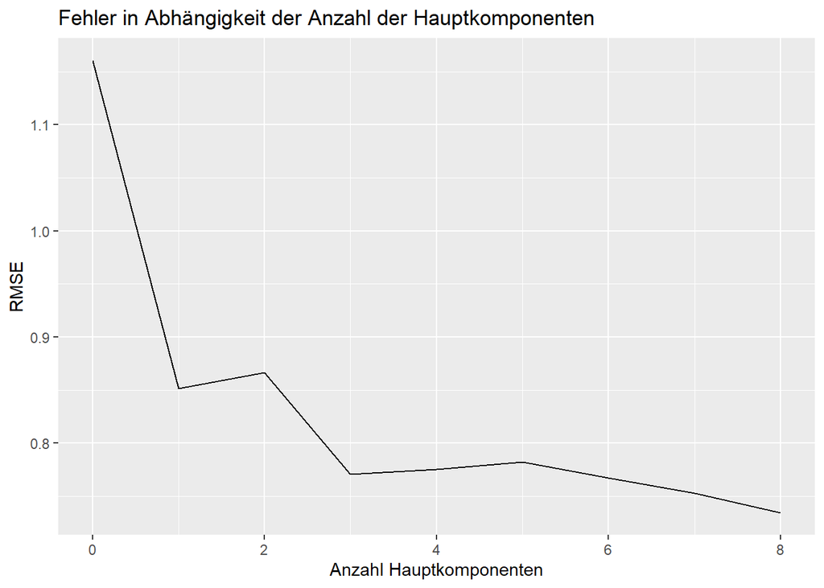

```r
rmsep <- RMSEP(pca_regression)
rmsep_values <- rmsep[["val"]][seq(1,17,2)]
ggplot(mapping=aes(x=0:8, y=rmsep_values)) +
  geom_line() +
  labs(title="Fehler in Abhängigkeit der Anzahl der Hauptkomponenten", y="RMSE", x="Anzahl Hauptkomponenten")
```

Der geringste Fehler tritt mit allen 8 Komponenten auf. Allerdings sinkt der Fehler ab 3 Hauptkomponenten nur noch gering und steigt sogar bei 5 Hauptkomponenten an. Darum werden 3 Hauptkomponenten als optimale Anzahl im folgenden Modell gewählt.

#### PCA Regression mit optimaler Hauptkomponentenanzahl

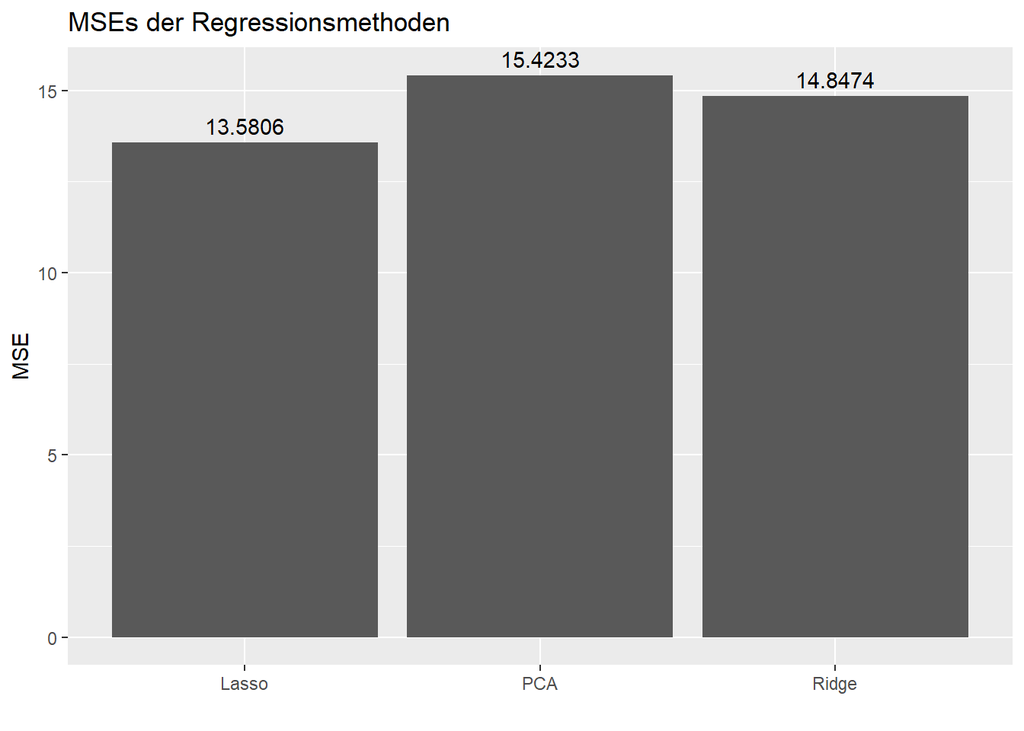

```r
num_comp <- 3
train <- subset(prostate, train==TRUE)
test <- subset(prostate, train==FALSE)

pca_regression <- pcr(lpsa~lcavol+lweight+age+lbph+svi+lcp+gleason+pgg45, data=train,scale=TRUE)
y_predict <- predict(pca_regression, test, ncomp=num_comp,)
mse_optimal_lambda_rr <- 14.8474
mse_optimal_lambda_lasso <- 13.5806
mse_pca <- sum((test$lpsa - y_predict)**2)
mse_pca <- round(mse_pca, 4)
mses <- c(mse_pca, mse_optimal_lambda_rr, mse_optimal_lambda_lasso)
ggplot(mapping=aes(x=c("PCA", "Ridge", "Lasso"), y=c(mses))) +
  geom_bar(stat = "identity") +
  labs(title="MSEs der Regressionsmethoden" ,y="MSE", x="") +
  geom_text(aes(label=mses), vjust=-0.5)
```

Die Lasso-Methode erzielt im vorgegebenen Trainings-/Testdatensatz den geringsten quadratischen Fehler. Die Varianz der MSEs ist nicht hoch, das bedeutet, dass die Methoden sehr ähnliche Ergebnisse liefern hinsichtlich ihrer Präzision in diesem Beispiel.

### PLS Regression

Die PLS-Regression funktioniert ähnlich wie die PCA-Regression. Die Variablen (x1,…, xp) werden bei der PLS-Regression vor der Hauptkomponentenanalyse anhand ihrer Korrelationen zur Zielgröße gewichtet werden. Dafür werden p lineare Regressionen durchgeführt.

```r
set.seed(1)
pls_regression <- plsr(lpsa~lcavol+lweight+age+lbph+svi+lcp+gleason+pgg45, data=prostate,scale=TRUE, validation="CV")
summary(pls_regression)
```

```
## Data:    X dimension: 97 8
##  Y dimension: 97 1
## Fit method: kernelpls
## Number of components considered: 8
##
## VALIDATION: RMSEP
## Cross-validated using 10 random segments.
##        (Intercept)  1 comps  2 comps  3 comps  4 comps  5 comps  6 comps
## CV            1.16   0.8024   0.7508   0.7351   0.7374   0.7349   0.7351
## adjCV         1.16   0.8011   0.7476   0.7330   0.7338   0.7312   0.7314
##        7 comps  8 comps
## CV      0.7347   0.7346
## adjCV   0.7311   0.7310
##
## TRAINING: % variance explained
##       1 comps  2 comps  3 comps  4 comps  5 comps  6 comps  7 comps  8 comps
## X       41.30    53.96    66.37    78.64    84.35    90.34    94.36   100.00
## lpsa    54.62    63.55    65.31    66.12    66.32    66.34    66.34    66.34
```

```r
rmsep <- RMSEP(pls_regression)
rmsep_values <- rmsep[["val"]][seq(1,17,2)]
min_fehler <- which(rmsep_values == min(rmsep_values)) -1  # - 1 weil index startet bei 1, Komponenten bei 0
print(paste("kleinster Fehler: ", min_fehler))
```

```
## [1] "kleinster Fehler:  8"
```

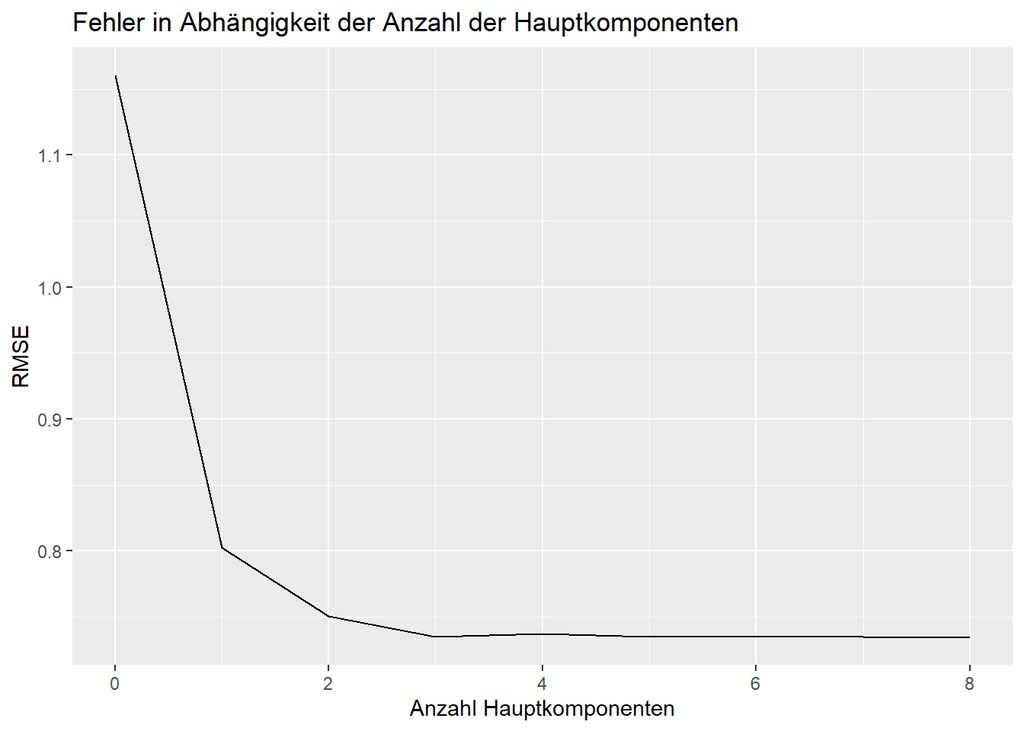

```r
ggplot(mapping=aes(x=0:8, y=rmsep_values)) +
  geom_line() +
  labs(title="Fehler in Abhängigkeit der Anzahl der Hauptkomponenten", y="RMSE", x="Anzahl Hauptkomponenten")
```

Der kleinste Fehler ist wieder bei 8 Komponenten. Der Fehler sinkt nach 3 Hauptkomponenten nicht mehr erheblich, darum wird er als Optimum gewählt.

#### PLS-Regression mit optimaler Hauptkomponentenanzahl

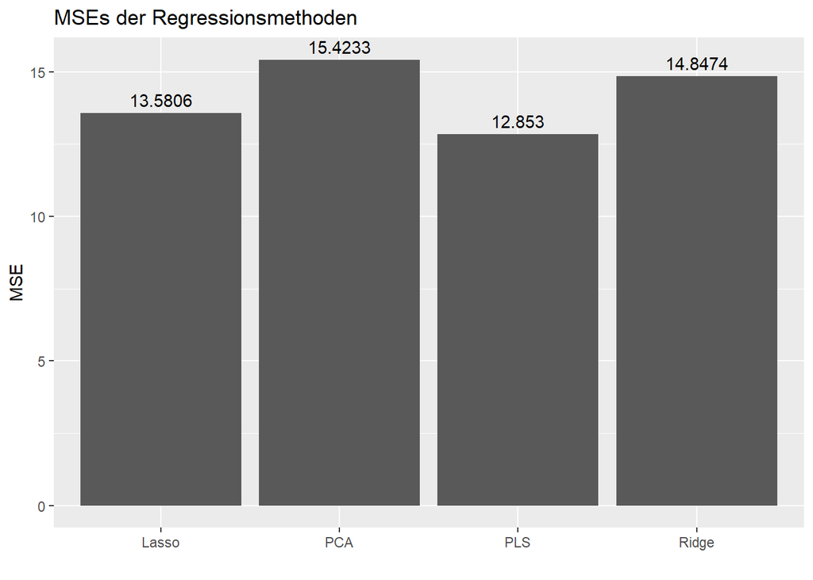

```r
num_comp <- 3

pls_regression <- plsr(lpsa~lcavol+lweight+age+lbph+svi+lcp+gleason+pgg45, data=train,scale=TRUE)
y_predict <- predict(pls_regression, test, ncomp=num_comp,)
mse_pls <- sum((test$lpsa - y_predict)**2)
mse_pls <- round(mse_pls, 4)
mses <- c(mse_pca, mse_pls, mse_optimal_lambda_rr, mse_optimal_lambda_lasso)
ggplot(mapping=aes(x=c("PCA", "PLS", "Ridge", "Lasso"), y=c(mses))) +
  geom_bar(stat = "identity") +
  labs(title="MSEs der Regressionsmethoden" ,y="MSE", x="") +
  geom_text(aes(label=mses), vjust=-0.5)
```

Der Fehler der PLS-Regression ist am geringsten, das bedeutet die PLS Regression kann anhand des vorgegebenen Trainingsdatensatzes die Testdaten am besten vorhersagen.

# Zufallszahlen

### Poisson- und Exponentialverteilung

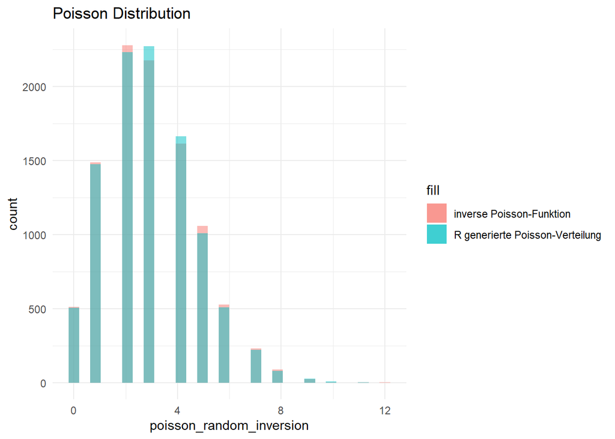

```r
library(ggplot2)

set.seed(1)
n <- 10000
uniform_random <- runif(n)
lambda = 3

poisson_random_inversion <- qpois(uniform_random, lambda) # Gibt den Wert der inversen Poisson-Funktion für die kumulative Dichte zurück. Q(p) = F^-1(p)

poisson_random_r <- rpois(n, lambda = lambda) # random generated poisson-distributed numbers in R

ggplot()+
  geom_histogram(aes(poisson_random_inversion, fill="inverse Poisson-Funktion"), alpha=0.5) +
  geom_histogram(aes(poisson_random_r, fill="R generierte Poisson-Verteilung"), alpha=0.5) +
  labs(title = "Poisson Distribution") +
  theme_minimal()
```

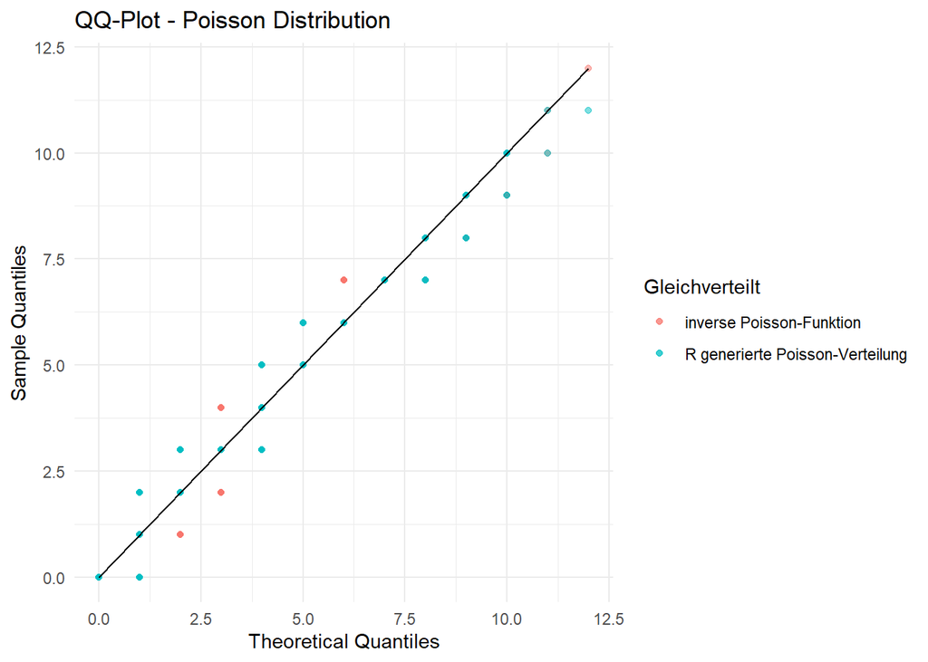

```r
ggplot() +
  stat_qq(aes(sample = poisson_random_inversion, color="inverse Poisson-Funktion"), distribution=qpois, alpha=0.5, dparams = list(lambda = lambda)) +
  stat_qq(aes(sample = poisson_random_r, color = "R generierte Poisson-Verteilung"), distribution=qpois, alpha=0.5, dparams = list(lambda = lambda)) +
    stat_qq_line(aes(sample = poisson_random_r),distribution=qpois, dparams = list(lambda = lambda))+
  labs(title = "QQ-Plot - Poisson Distribution",
       x = "Theoretical Quantiles",
       y = "Sample Quantiles") +
  theme_minimal() +
  labs(color=c("Gleichverteilt","R zufallsgeneriert"))
```

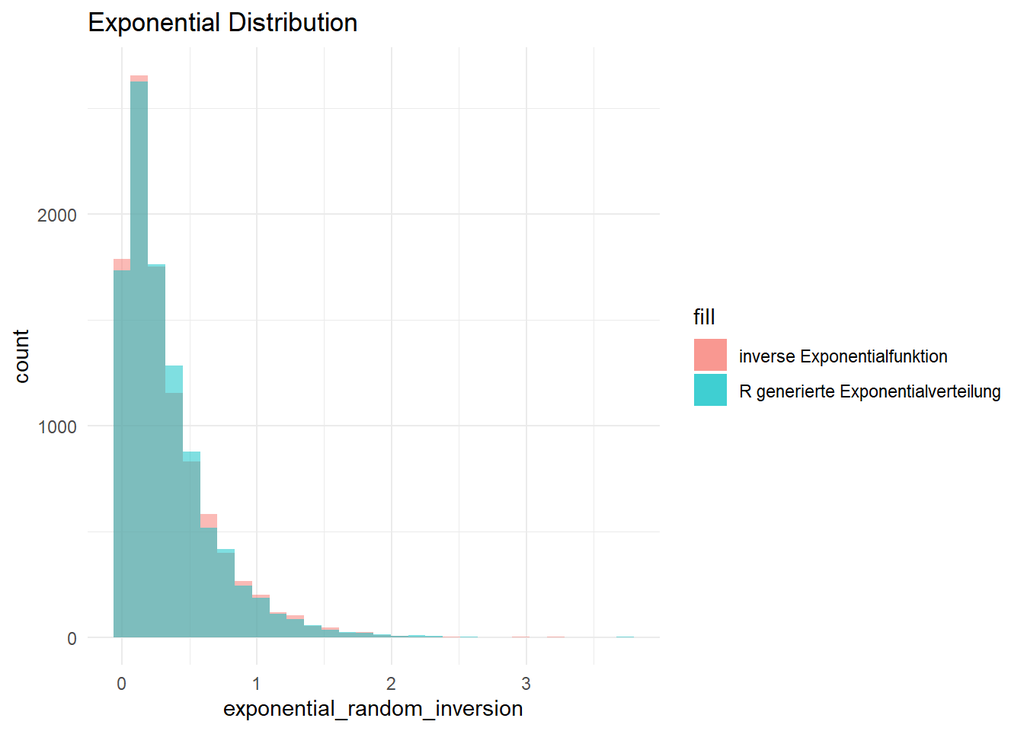

```r
# doing the same with the exponential distribution
exponential_random_inversion <- -log(1 - uniform_random) / lambda
exponential_random_r <- rexp(n, rate =lambda)


ggplot()+
  geom_histogram(aes(exponential_random_inversion, fill="inverse Exponentialfunktion"), alpha=0.5) +
  geom_histogram(aes(exponential_random_r, fill="R generierte Exponentialverteilung"), alpha=0.5) +
  labs(title = "Exponential Distribution") +
  theme_minimal()
```

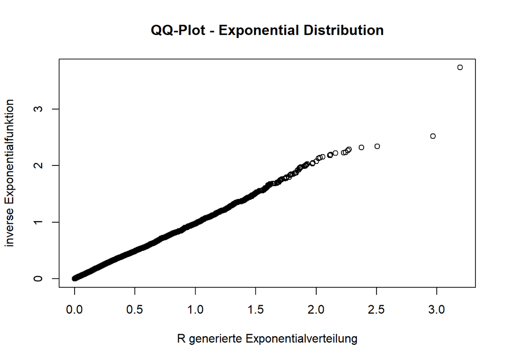

```r
qqplot(exponential_random_inversion, exponential_random_r,
       ylab="inverse Exponentialfunktion",
       xlab="R generierte Exponentialverteilung",
       main="QQ-Plot - Exponential Distribution")
```

Die Plots zeigen, dass es sich bei den transformierten gleichverteilten Zufallszahlen, um die gleiche Verteilung wie die der in R zufallsgenerierten Verteilungen handelt.

### Normalverteilung

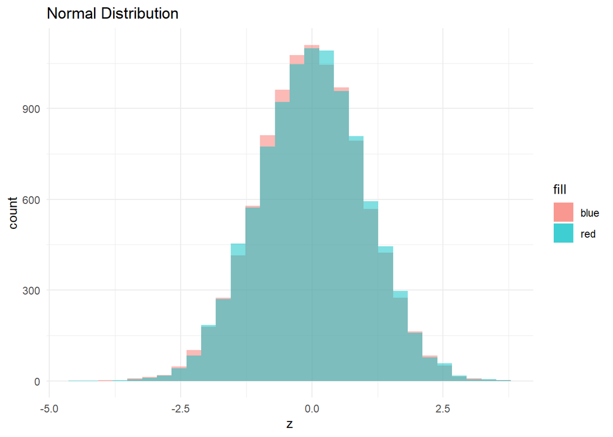

```r
n <- 10000
u <- runif(n)
v <- runif(n)
z <- cos(2*pi*u)*sqrt(-2*log(v)) # Transformation gleichverteilt -> normalverteilt
normal_random_r <- rnorm(n)

ggplot()+
  geom_histogram(aes(z, fill="blue"), alpha=0.5) +
  geom_histogram(aes(normal_random_r, fill="red"), alpha=0.5) +
  labs(title = "Normal Distribution") +
  theme_minimal()
```

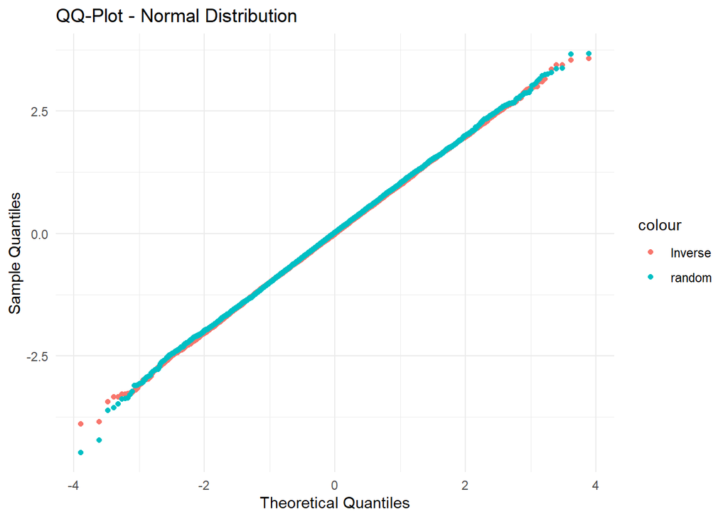

```r
ggplot() +
  geom_qq(aes(sample = z, col="Inverse")) +
  geom_qq(aes(sample = normal_random_r, col="random")) +
  labs(title = "QQ-Plot - Normal Distribution",
       x = "Theoretical Quantiles",
       y = "Sample Quantiles") +
  theme_minimal()
```

Die Verteilung der transformierten Zufallszahlen liegen auf den von R generierten normalverteilten Zufallszahlen.

### Zufallszahlen generieren

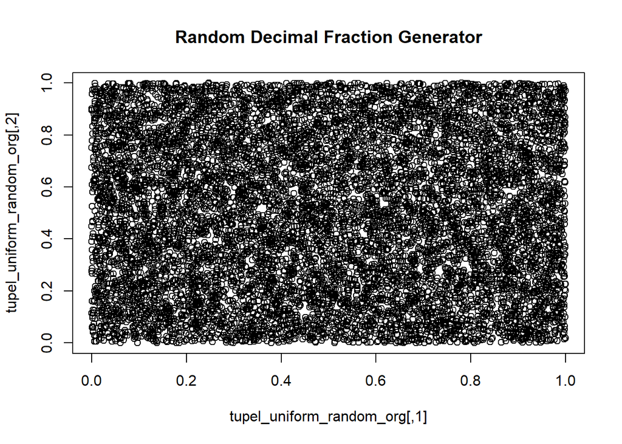

```r
# Random.org erzeugte Zufallszahlen
file_path <- "data/random_org.txt"
uniform_random_org <- scan(file_path, sep="\n")
tupel_uniform_random_org <- embed(uniform_random_org, 2)
plot(tupel_uniform_random_org, main="Random Decimal Fraction Generator")
```

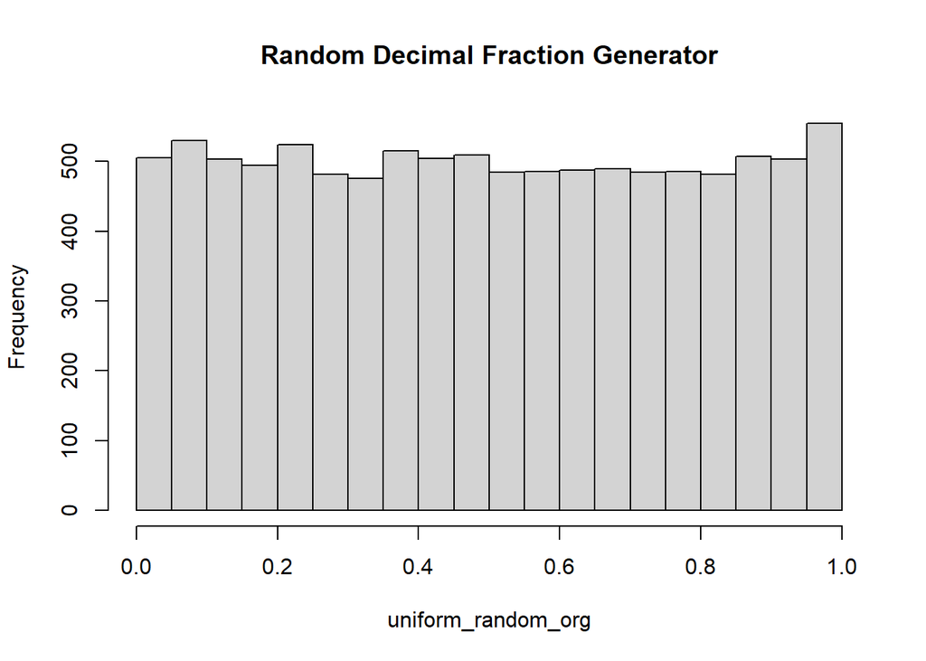

```r
hist(uniform_random_org, main="Random Decimal Fraction Generator")
```

```r
# Mittelquadratverfahren von Neumann
seed <- sample(10000000:99999999, 1) # beliebige 8-stellige Zahl
n <- 10000
k <- 8
uniform_random_neumann <- c()
xn <- seed^2
for(i in 1:n){
  xn_string <- as.character(xn)
  middle_digits <- substr(xn_string, start=(nchar(xn_string)/2 - (k/2-1)), stop=(nchar(xn_string)/2 +k/2)) #get the 8 middle digits of the squared xn
  xn <- as.integer(middle_digits)
  uniform_random_neumann <- c(uniform_random_neumann, xn)
  if(xn == 0){
    print("xn = 0")
    break
  }
  xn <- xn^2
}
```

```
## [1] "xn = 0"
```

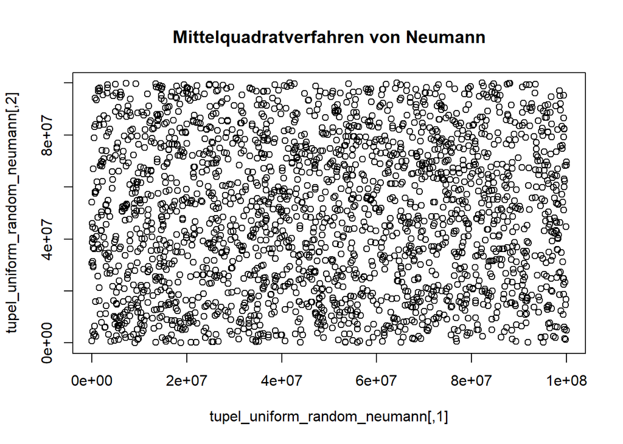

```r
tupel_uniform_random_neumann <- embed(uniform_random_neumann, 2)

plot(tupel_uniform_random_neumann, main="Mittelquadratverfahren von Neumann")
```

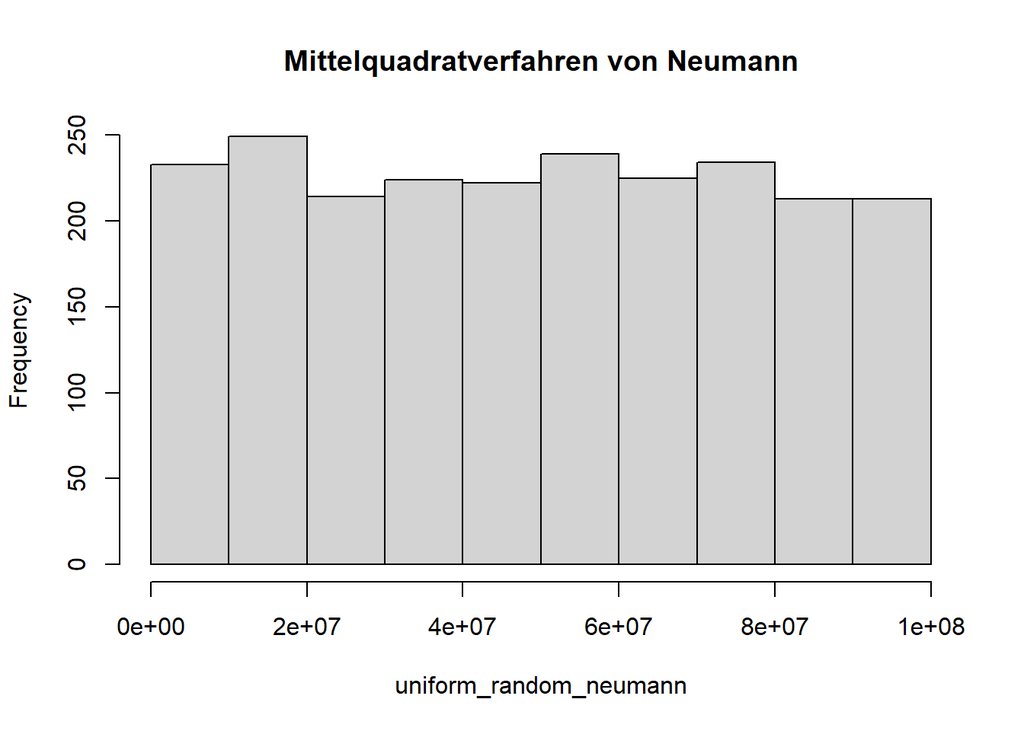

```r
hist(uniform_random_neumann, main="Mittelquadratverfahren von Neumann")
```

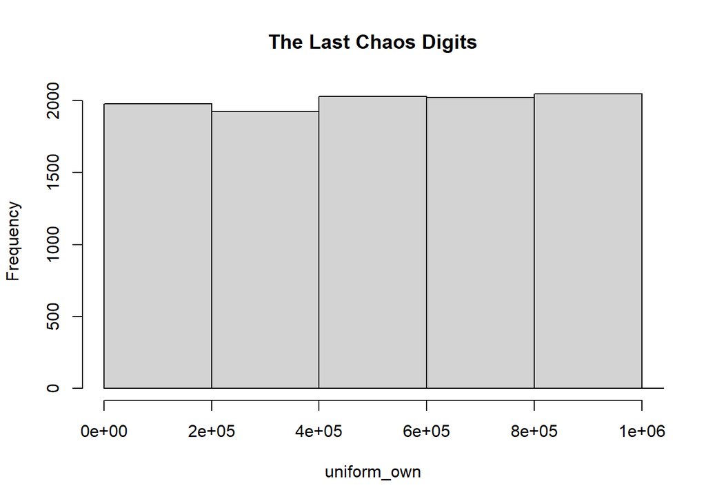

```r
# eigenes Verfahren
a <- sample(100^2:100^3, 3) # Startwerte initialisieren
z <- (a[1]*1+a[2]*2+a[3]*3) # z berechnen aus Startwerten
k <- 6 # Anzahl an Digits, die in die Gleichverteilung kommen

uniform_own <- c()
for(i in 1:n)
{
  # weise die letzten k Digits dem neuen z-Wert zu
  z_string <- as.character(z)
  last_k_digits <- substr(z_string, start=(nchar(z_string)+1-k), stop=(nchar(z_string)))
  z <- as.integer(last_k_digits)
  uniform_own <- c(uniform_own,z)
  a <- c(a[2], a[3], z) # aktualisiere Vektor a: z an dritter Position. Entferne a1
  z <- (a[1]*1+a[2]*2+a[3]*3) # aktualisiere z anhand des a Vektors
}
hist(uniform_own, main="The Last Chaos Digits", xlim=c(0,1000000))
```

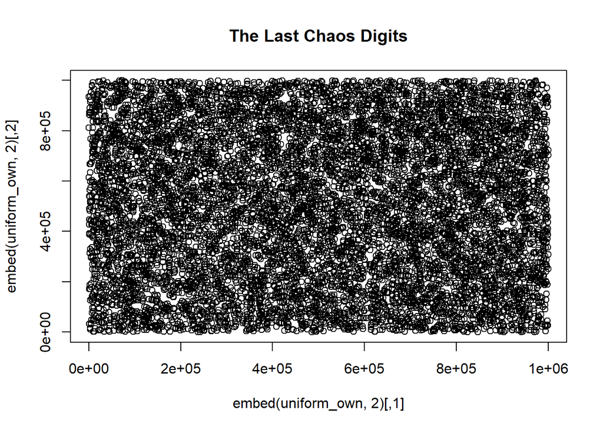

```r
plot(embed(uniform_own, 2), main="The Last Chaos Digits", xlim=c(0,1000000), ylim=c(0,1000000))
```

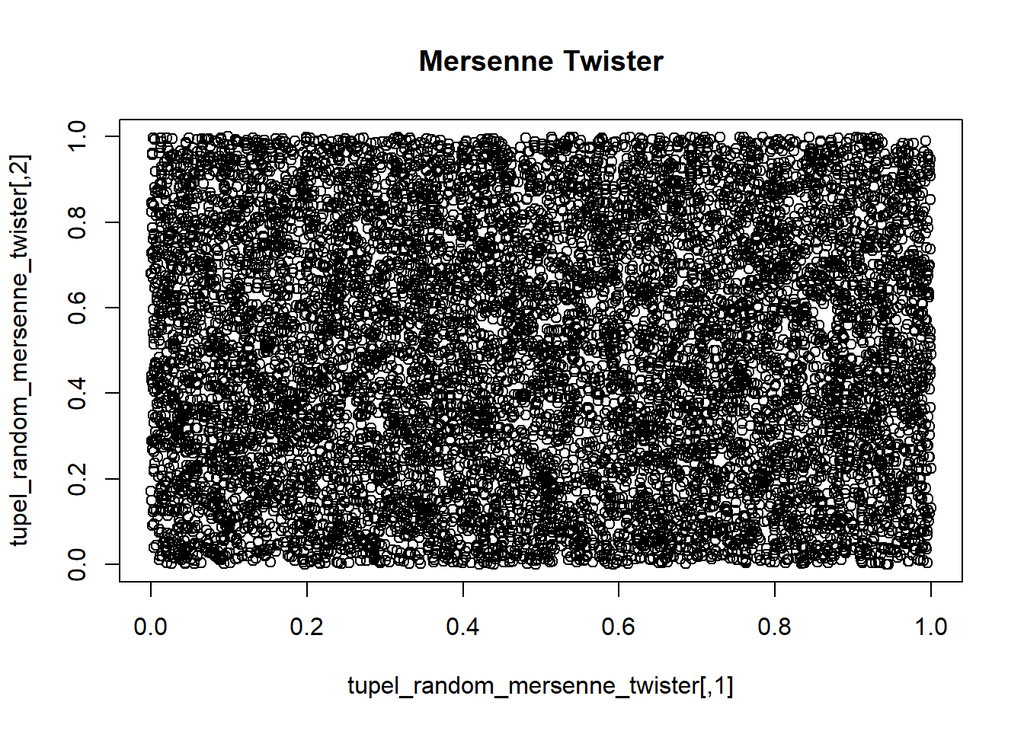

```r
# Mersenne twister
random_mersenne_twister <- runif(n)
tupel_random_mersenne_twister <- embed(random_mersenne_twister,2)
plot(tupel_random_mersenne_twister, main="Mersenne Twister")
```

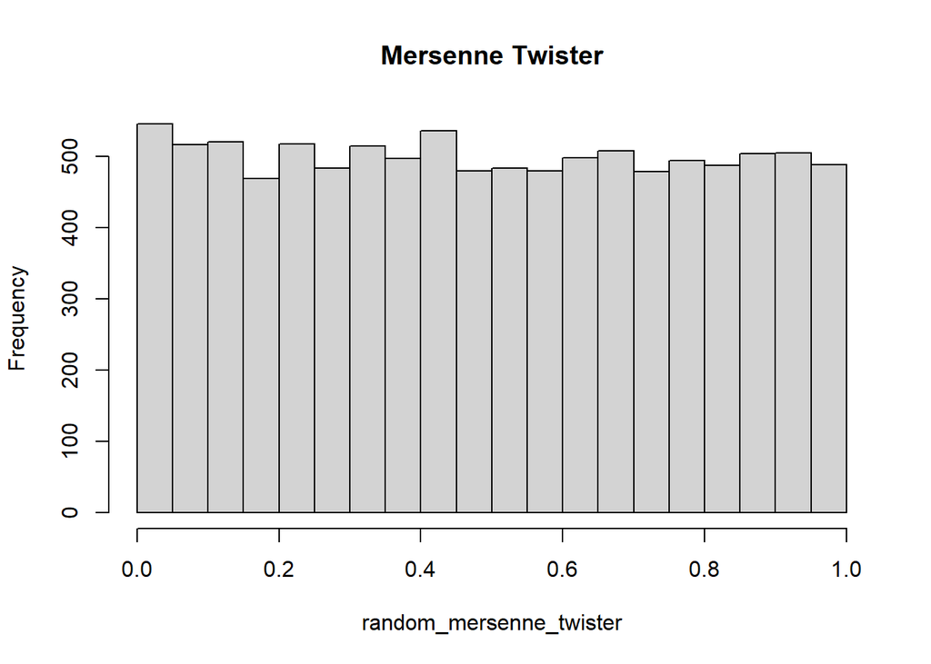

```r
hist(random_mersenne_twister, main="Mersenne Twister")
```

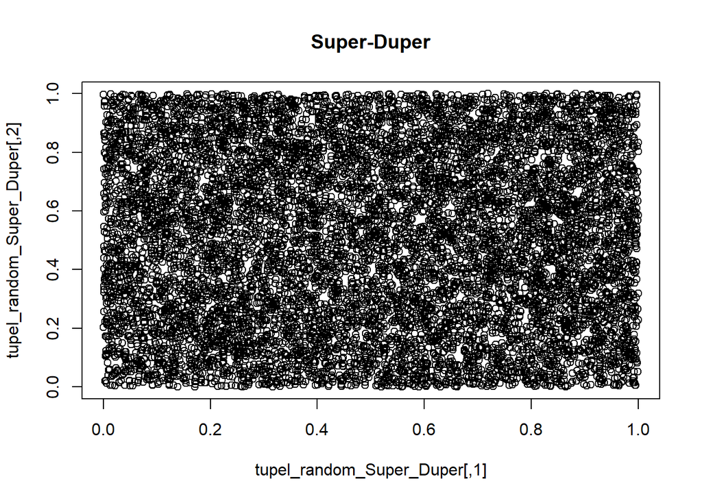

```r
#
RNGkind("Super-Duper")
random_Super_Duper <- runif(n)
tupel_random_Super_Duper <- embed(random_Super_Duper,2)
plot(tupel_random_Super_Duper, main="Super-Duper")
```

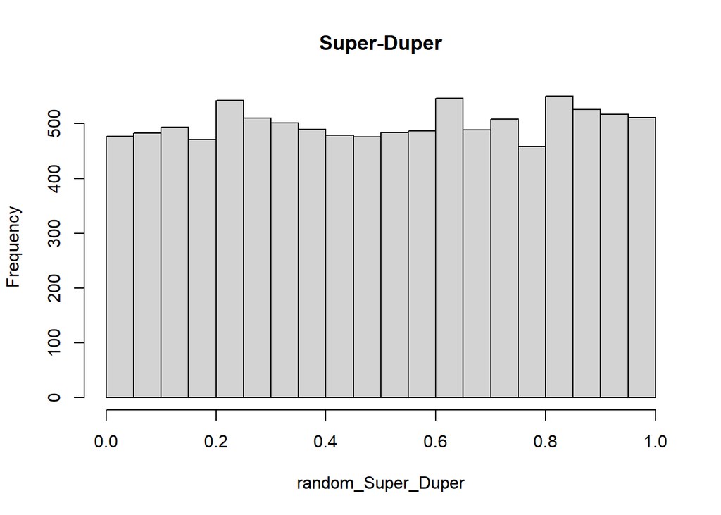

```r
hist(random_Super_Duper, main="Super-Duper")
```